# Spotifys populaarsete lugude omadused

Andreas Vija, Rasmus Maide

## Sissejuhatus

Spotify on muusika voogedastuse teenus, millel on 2018. mai seisuga 170 miljonit aktiivset kasutajat 65 riigist üle maailma. Populaarseimaid lugusid on seal kuulatud enam kui miljard korda. Spotify koostab iga päeva kohta edetabeleid, mis näitavad nii regiooni kaupa kui ülemaailmselt, mitu korda päevas lugu kuulati. Me keskendume oma uuringus vahemikus 01.01.2017-09.01.2018 moodustatud ülemaailmsele TOP 200 edetabelile. Kõikide lugude kohta on Spotifyl ka metaandmed, mis kirjeldavad loo omadusi. Neid uurides on võimalik ennustada, mis teeb loost populaarse loo.

## Andmed

Iga loo edetabelikoha andmed pärinevad Kaggle’is avaldatud [andmestikust](https://www.kaggle.com/edumucelli/spotifys-worldwide-daily-song-ranking/data). Metaandmed lugude kohta pärinevad Spotify API-st ning see andmestik koos selle omandamiseks kasutatud koodiga on saadaval [GitHubis](https://github.com/andreasvija/spotify-2017). Seal asub ka andmeanalüüsi kood.

Metaandmed lugude kohta koosnevad järgmistest näitajatest:

Akustilisus (*acousticness*) - usaldusnäitaja, mis näitab, kas lugu on akustiline. Mida kõrgem näitaja, seda suurema tõenäosusega on akustiline.

Tantsitavus (*danceability*) - kirjeldab, kas lugu sobib tantsimiseks, arvestades tempot, rütmi stabiilsust, tugevust ja üleüldist regulaarsust. Kõrgem näitaja tähendab, et lugu on rohkem tantsitav.

Kestus (*duration_ms*) - loo pikkus millisekundites

Energia (*energy*) - tunnetuslik näitaja loo intensiivsuse ja aktiivsuse kohta. Energilised lood on tavaliselt kiired ja valjud, näiteks *death metal* on energiline, klassikaline muusika ei ole.

Instrumentaalsus (*instrumentality*) - näitaja, mis ennustab, kas lugu sisaldab sõnu. “Oh” ja “ah” helid loetakse siin instrumentaalseks.

Helistik (*key*) - helistik, milles laul on. Arv näitab heliklassi.

Elavus (*liveness*) - tuvastab publiku kuuldavust loos. Kõrge väärtus tähendab suurt tõenäosust, et lugu esitati *live*’s.

Valjus (*loudness*) - keskmine loo valjus detsibellides

Helilaad (*mode*) - loo helilaad, kas mazoor (1) või minoor (0)

Kõnesus (*speechiness*) - tuvastab loos kõneletud sõnade osakaalu. Kõrgem väärtus on näiteks räpil, madalam väärtus meloodilisemal muusikal

Tempo (*tempo*) - Hinnang loo tempole lööke minutis (BPM)

Taktimõõt (*time_signature*) - hinnang, mitu lööki on ühes taktis

Positiivsus (*valence*) - hinnang, kui positiivselt lugu kõlab. Kõrgem näitaja on positiivsema kõlaga lool, madalam negatiivse kõlaga.

Edetabeli andmestikus on kirjed ka iga regiooni TOP 200 lugude kohta, kuid me vaatame ainult neid lugusid, mis on olnud ülemaailmses TOP 200 edetabelis. Peale andmete puhastamist on 73246 kirjet edetabelikohtade kohta, kus ühe kirje moodustab ühe laulu edetabelikoht konkreetsel päeval ja 1296 kirjet lugude kohta, igas kirjes on laul ning selle omadused.

## Lugude liikumine edetabelis

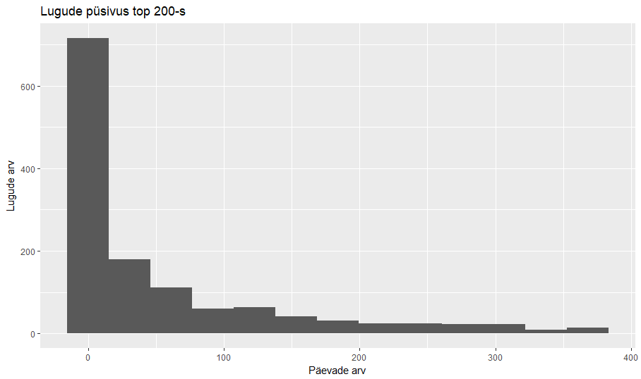

Jooniselt on näha, et üle 60% lugudest püsivad TOP 200 edetabelis vähem kui kuu aega. Esines ka lugusid, mis püsisid edetabelis terve vaadeldava aja.

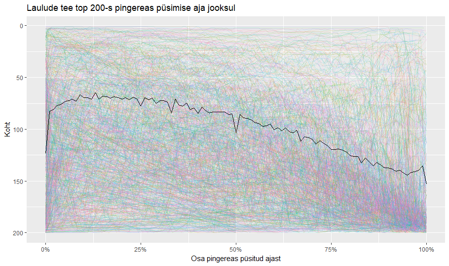

Järgmisena vaatame, kuidas laulud liiguvad oma edetabelis oldud aja jooksul. Joonisel on värviliste joontena iga laulu liikumine edetabelis selle aja jooksul, kui need edetabelis olid. Must joon näitab iga protsendi kohta laulude keskmist positsiooni, kui oma kokku edetabelis oldud ajast oli just nii mitu protsenti päevi möödunud. Nagu võis arvata, siis laulud edetabelis saavutavad oma kõrghetke üsna kiiresti ning siis peamiselt langevad. Tabelis on mitmete oluliste portsentide juures koht madalam kui ümbritsevate protsentide juures. Seda põhjustab fakt, et vähem edetabelis olnud lood mõjutavad vaid teatud protsente. Näiteks kui lugu oli edetabelis vaid kolm päeva, siis selle esimese päeva koht läheb 0% alla, teise päeva koht 50% alla ning kolmanda päeva koht 100% alla. Kuna vähem aega edetabelis olevad lood ei jõua ilmselt eriti kõrgele, on kõikide nende protsentide juures näha langust.

## Seosed lugude omaduste vahel

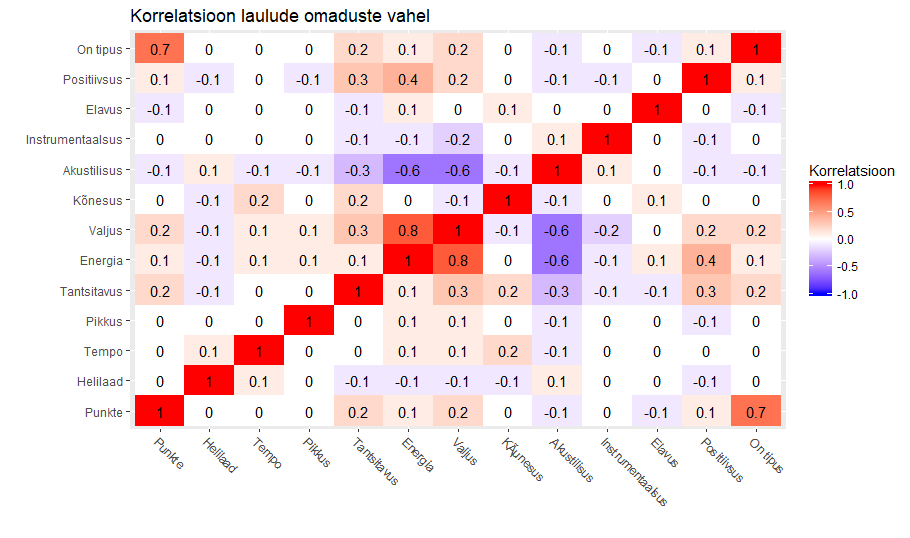

Nagu näha, on kõige sarnasemad omadused valjus ja energia ning mõlemaga on tugevalt negatiivselt korreleeritud akustilisus. Populaarseimad lood pole õnneks või kahjuks ühegi omadusega tugevalt seotud. Kõige tugevam korrelatsioon on populaarsetel lugudel tantsitavate ja valjude lugudega, veel väiksem seos positiivsete ning energiliste lugudega. Akustilised ja *live*’s esitatud lood edetabelites kõrgele ei jõua, seega on need omadused edetabeli populaarsusega negatiivselt korreleeritud. Kuigi need negatiivsed korrelatsioonid on väga väikesed, on need statistiliselt olulised, sest paljude lugude puhul on akustilisuse ning elavuse näitajad ühtmoodi väga madalad, mis vähendab korrelatsioonikordajat, sest nendel näiteks ühtemoodi mitteakustilistel lugudel võib olla väga erinev populaarsus. Et näha täpsemalt tugevaimate seoste sisu, näitab järgmine graafik seost valjususe, energia ja akustilisuse vahel.

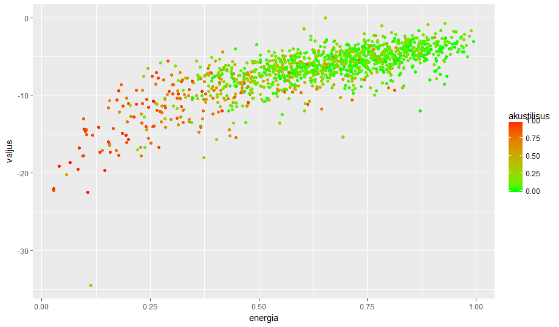

Esiteks on näha, et tõepoolest on roheliste täppidega tähistatud madal akustilisus seotud valjuse ja energiaga. Samuti võib tähele panna, et suurem osa lugusid on valjud, energilised ning pole akustilised. See on üsna ootuspärane, kuna eelmiselt jooniselt oli näha, et just need omadused aitavad lool olla edetabelis kõrgemal. Seetõttu pole üllatav, et ka kõikide edetabelisse mahtunud lugude juures on just need omadused levinuimad.

[figure not shown]

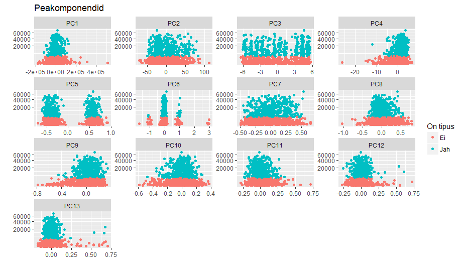

Kuna paljud omadused kirjeldavad lauludel sarnaseid tunnuseid, tegime lugudele peakomponentanalüüsi. Selle eesmärk on grupeerida omadused sarnasteks peakomponeniteks (PC), mis on laulude omaduste lineaarkombinatsioon. See grupeerimine kirjeldab lugude tegelikke erinevaid omadusi ning kui mõni neist on populaarsusega korreleeritud, võibki seal peituda populaarse loo võti. Kahjuks nagu ülalolevalt jooniselt näha, ei ole ükski tunnus oluliselt erinev populaarsete ja vähem populaarsete lugude hulgas.